# Midterm Project Nuggets

Ethan Leader

2026-03-10

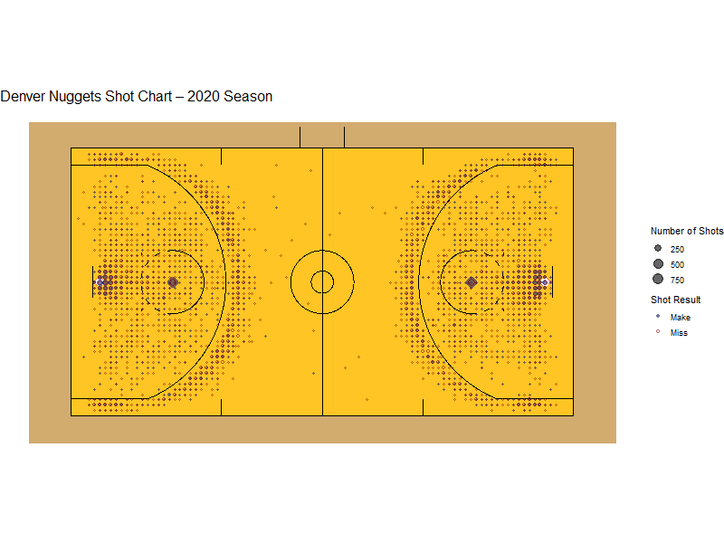

## 1. Shot attempts are heavily concentrated near the basket and in the corners

The densest clusters of shots appear directly under the basket and in both corners. This suggests a strong focus on high-value scoring areas either in close-range attempts or corner threes, which are typically more efficient than other shot types.

## 2. Three-point shooting is dominated all along the line

There is a clear arc of shot attempts just outside and along the three-point line, with especially high density in the corners and directly in front of the basket.

## 3. Mid-range shots are relatively infrequent

The area between the painted circle in front of the net and the three-point line shows noticeably fewer shot attempts. This indicates that few shot attempts are made here, likely because they are less efficient compared to shots at the rim or from three-point range. Or they are blocked a lot more in other games.

## 4. More Free-throws are made than missed

We can tell from the gif that the red circle, not outlined is smaller than the dark blue filled in circle. Which means that the nuggets make their free-throws more often than they miss them.

## 5. Misses are more spread out than makes

Missed shots appear more dispersed across the court, while made shots tend to cluster in similar areas. This indicates that shot success is more consistent in optimal locations, while lower-percentage areas contribute more to missed attempts.

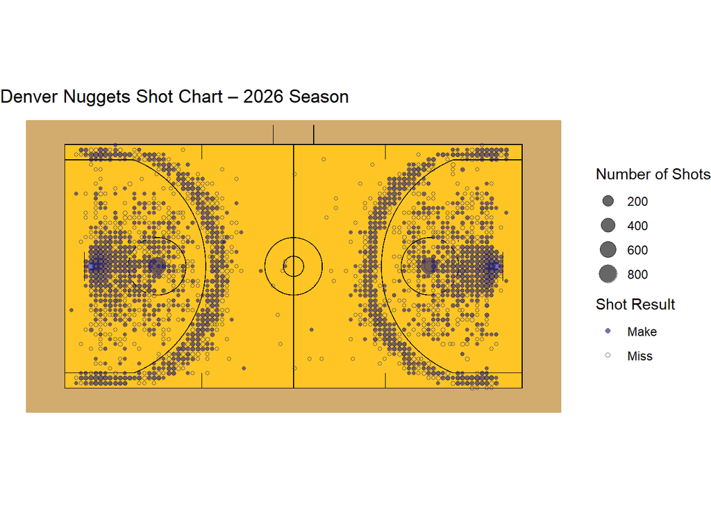

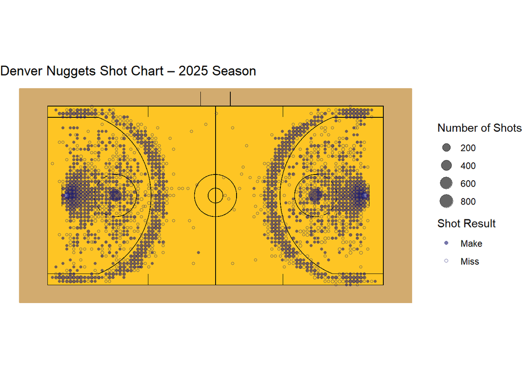

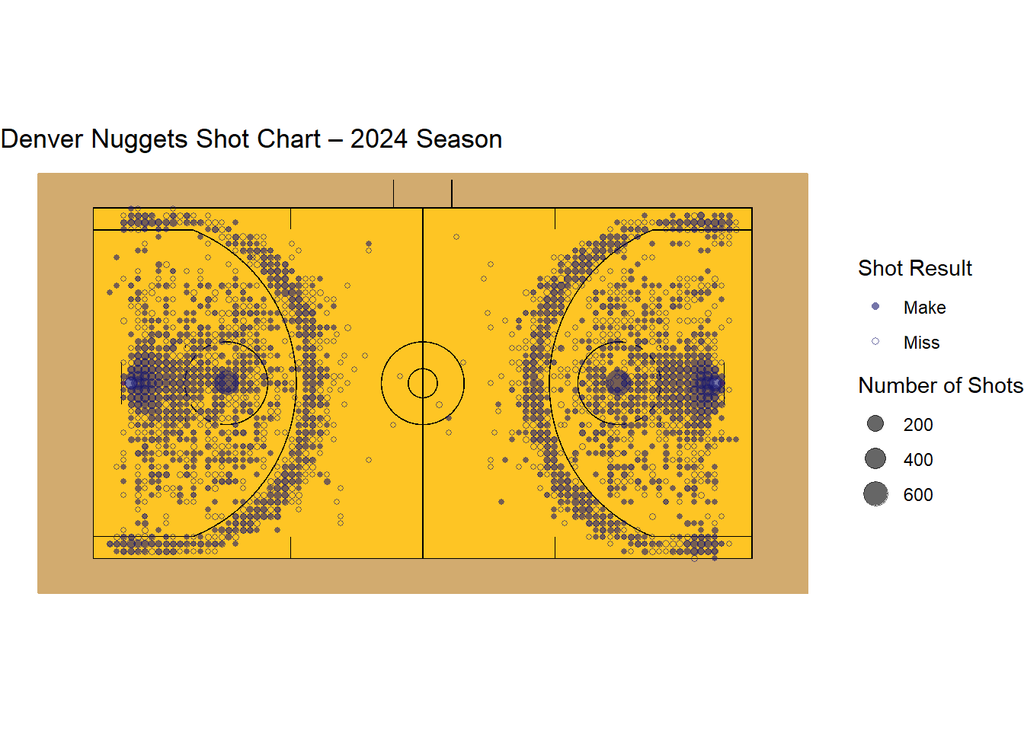

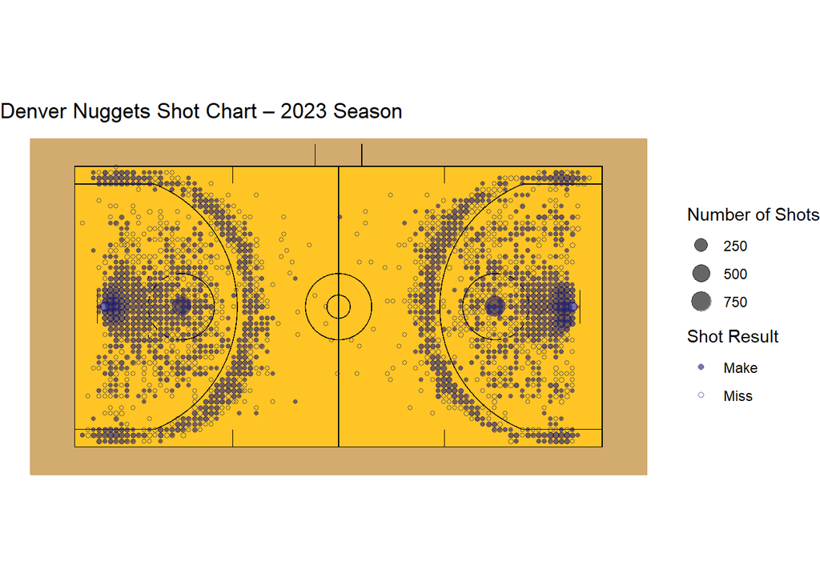

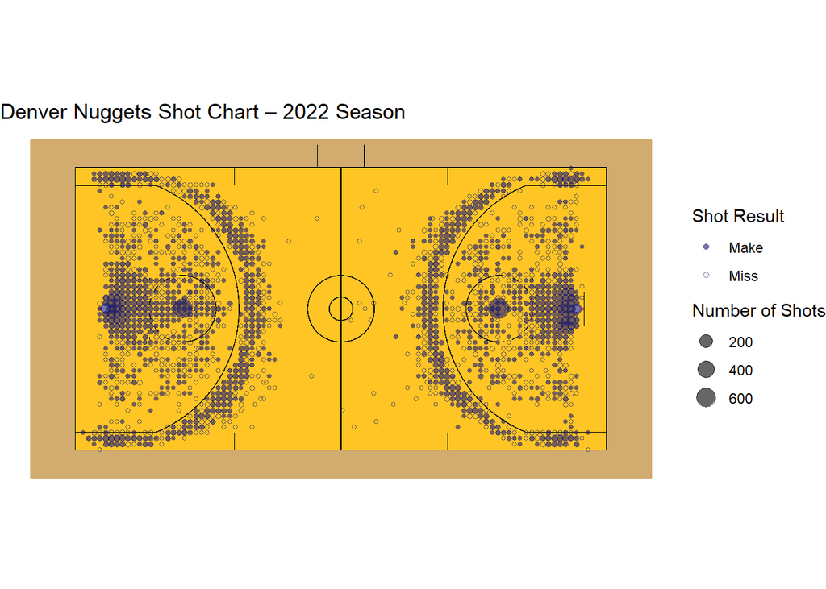

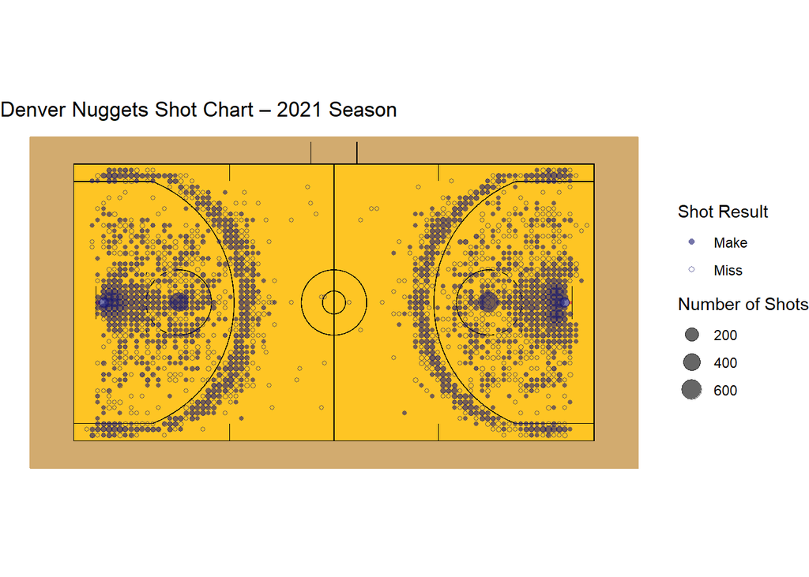

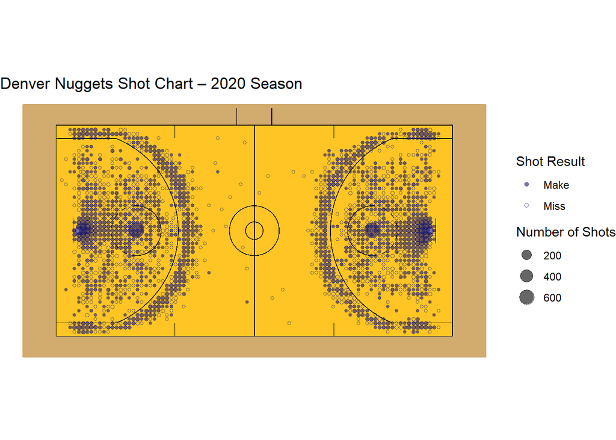

## Key Findings From Year to Year

## 1. Overall Similiar shot space

Across all years. The team has very similar shot attempt trends that were noted previously like near the hoop and around the 3 point line. These all vary slightly from year to year though.

Although it is mostly just variation from the years, there is a trend from 2020 to 2026 where the three point attempts are a little further and further from the 3 point line. This is likely due to coaching staff finding it more efficient to shoot a little past it. But, could be efficient to run some drills to shoot closer.

## 3. Team struggles to make shots at the end of the round 3-point line

The team has struggled with this in the early years, then slightly get better, then are getting worse again. Where the 3 point line ends curving off and becomes straight many shots are missed there. It might be worth avoiding these areas for shots or running drills to practice here.

# Deeper dive

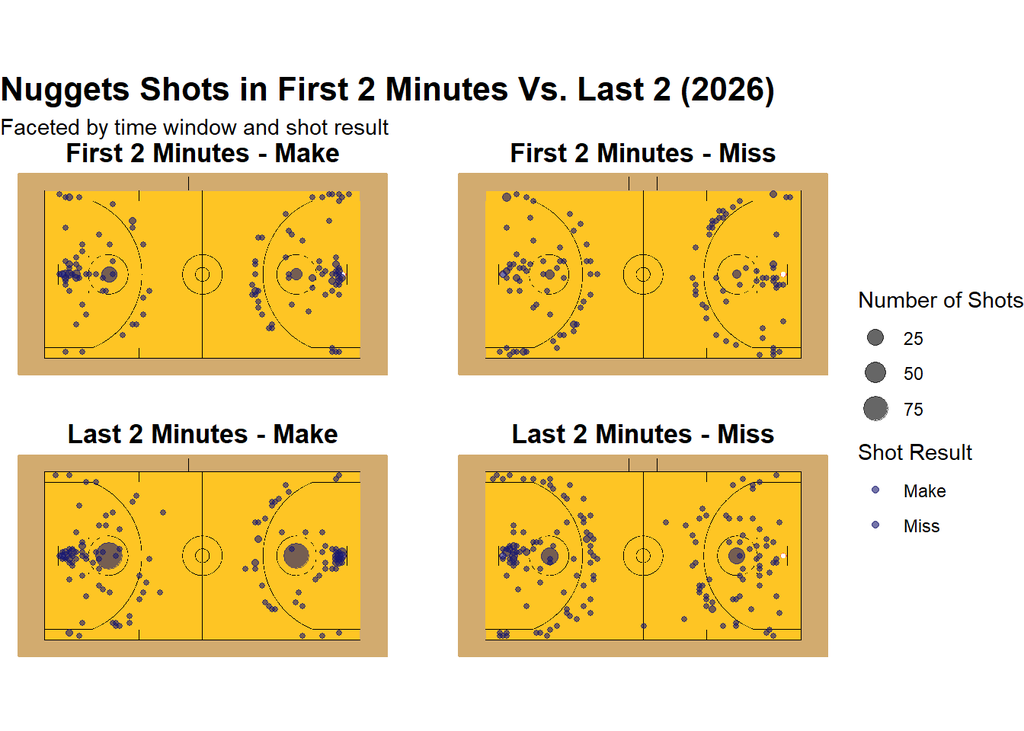

For this graphic I used time as a new variable to compare the shots made and not made in the first 2 minutes of the game to the shots made and not made in the last 2 minutes of the game. Here are my biggest takeaways with this information

## - 2-point shots

2-point shots are made more often in the last two minutes of the game vs the first two minutes of the game.

## - 3-point shots

there are more 3 point shot attempts in the last 2 minutes of the game than in the first 2 minutes. likely due to teams going for big risks in shots to try and regain the lead.

## - Missed shots

Shots missed in the last 2 minutes of the game are more scatterd all across the court where the made ones are very clustered. In the first 2 minutes both missed shots and made shots have a similar clustering pattern.

## - Free throws

More free throw attempts are made in the last 2 minutes of the game than the first. I imagine this is because players are under pressure and perform more fouls in the last 2 minutes than in the first.